# EDS213_week2_exercise1

Joe DeCesaro

10/6/2021

```r
library(tidyverse)
library(dataRetrieval)
library(here)
library(metajam)
```

# Exercise 1

```r
siteNumber_VT <- "11118500"
parameter_VT <- "00060"  # Discharge
startDate_VT <- "2000-10-05"
endDate_VT <- "2020-10-05"

discharge_VT <- readNWISdv(siteNumber_VT, parameter_VT, startDate_VT, endDate_VT)

discharge_VT <- discharge_VT %>%
   rename(x_discharge = X_00060_00003,
          date = Date)
```

Plot

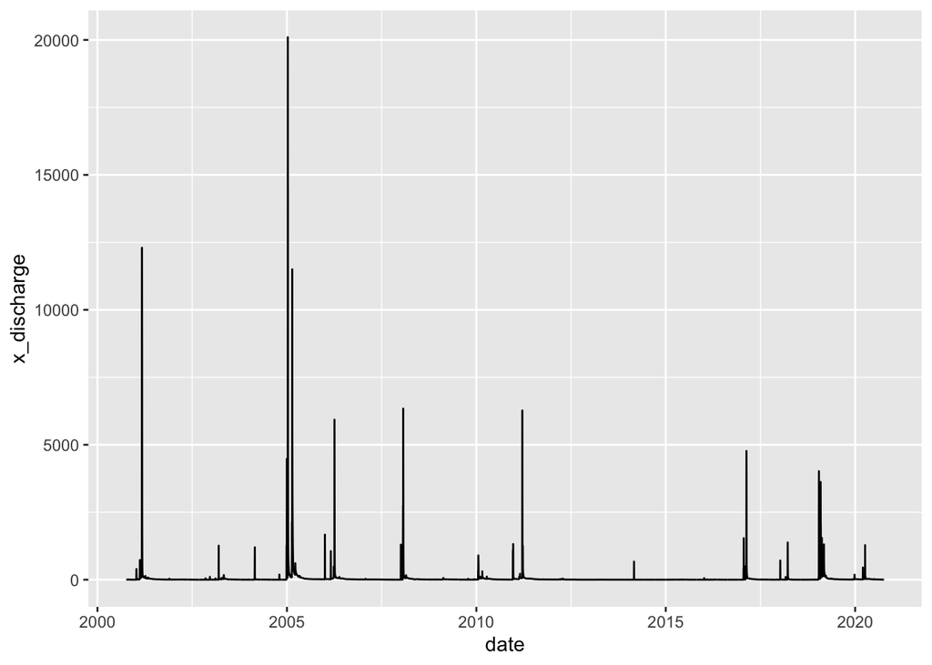

```r
ggplot(data = discharge_VT, aes(x = date, y = x_discharge)) +
  geom_line()
```

# Exercise 2

Code chunk is commented out so that it does not download the data every time it is run.

```r
# data_obj <- "https://knb.ecoinformatics.org/knb/d1/mn/v2/object/urn%3Auuid%3A7fc6f6db-c5ea-426a-a743-1f2edafb43b8"
# path <- here()

# download_d1_data(data_url = data_obj, path = path)
```

Read in the data

```r
meta_data <- read_csv(here("household_language", "household_language__summary_metadata.csv"))
total_household_data <- read_d1_files(here("household_language"))
hh_data <- total_household_data$data
```

Write a piece of code that will compute the percentage of Alaskan household speaking only English for the year 2009 to 2015

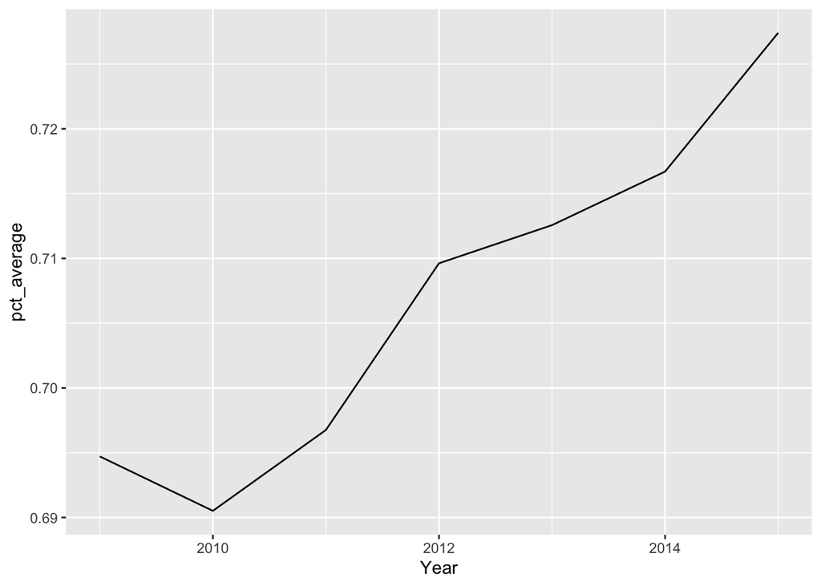

```r
only_english <- hh_data %>%
  filter(Year >= 2009,
         Year <= 2015,
         !total == 0) %>%
  mutate(eng_pct = speak_only_english/total) %>%
  select(Year, SASAP.Region, city, total,speak_only_english,eng_pct) %>%
  group_by(Year) %>%
  summarise(pct_average = mean(eng_pct))

ggplot(only_english, aes(x = Year, y = pct_average)) +
  geom_line()
```

# Assignment 2.1

```r
siteNumber_SP <- "11113500"
parameter_SP <- "00060"  # Discharge
startDate_SP <- "2021-10-04T00:00Z"
endDate_SP <- "2021-10-05T00:00Z"

discharge_SP_VT <- readNWISuv(c(siteNumber_SP, siteNumber_VT),
                           parameterCd = parameter_SP,
                           startDate = startDate_SP,
                           endDate = endDate_SP)

discharge_SP_VT <- discharge_SP_VT %>%
   renameNWISColumns()
```

2. The best way to query multiple sites for the R package would be to concatenate the two site numbers to call both in at the same time in one dataframe. (SP = Santa Paula, VT = Ventura)

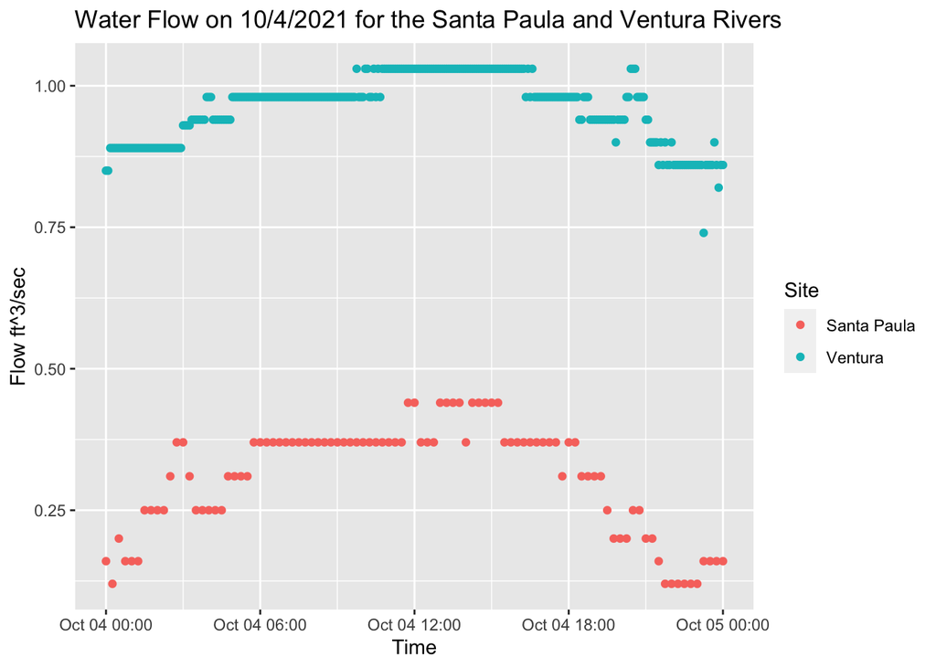

```r
ggplot(data = discharge_SP_VT, aes(x = dateTime, y = Flow_Inst)) +
  geom_point(aes(color = site_no)) +
  scale_color_discrete(name  = "Site",
                    labels = c("Santa Paula", "Ventura")) +
  labs(title = "Water Flow on 10/4/2021 for the Santa Paula and Ventura Rivers",
       x = "Time",
       y = "Flow ft^3/sec")
```

The flow peaked around noon to 13:00 for both locations. Ventura had greater flow overall.

# Assignment 2.2

See final graph below, this part was completed in class and the code is above in exercise 2.

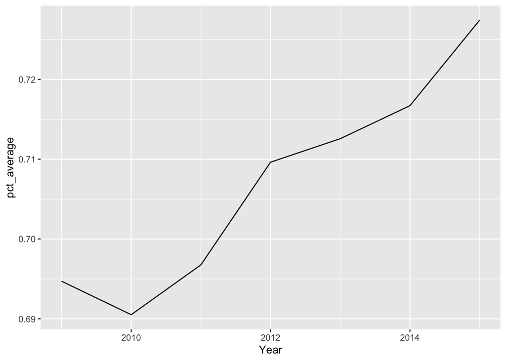

```r
ggplot(only_english, aes(x = Year, y = pct_average)) +
  geom_line()
```

Let’s try to compare it to the households that speak French. This part is done assuming that the “french_or_french_creole” captures all french speaking households.

```r
french <- hh_data %>%
  filter(Year >= 2009,
         Year <= 2015,
         !total == 0) %>%
  mutate(frn_pct = french_or_french_creole/total) %>%
  select(Year, SASAP.Region, city, total,french_or_french_creole,frn_pct) %>%
  group_by(Year) %>%
  summarise(pct_average = mean(frn_pct))
```

Something in the French data is causing it to be calculated as NA but I am not sure how this is happening.